# CSS692_HW2

Greg Tozzi

2/13/2017

### Importing and Exploring the Graph

The igraph package in R had difficulty parsing the provided Pajek version of the Attior graph. I wrote the helper function `import_attiro` in R to assist in importing the file and reducing it to an undirected graph. A plot of the resulting graph follows. In this plot, and the plots that follow, node groupings map to vertex colors.

All of the helper functions I wrote to assist in this assignment are available on GitHub.

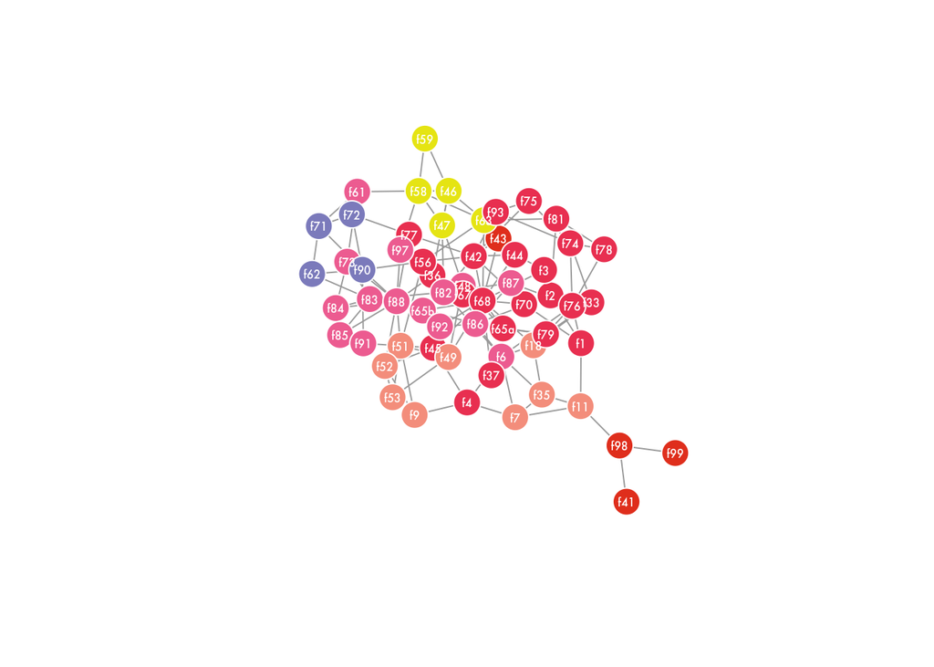

The modularity associated with the grouping assigned by the investigators can be computed by first treating the graph as undirected by applying the `as.undirected` function with `mode = collapse`, then applying the `modularity` function to the graph using the given groupings. The resulting modularity is 0.26 which is rather low.

### Applying the Girvan–Newman Algorithm

I applied the Girvan-Newman algoritm with a call to the igraph package’s `cluster_edge_betweenness` function. Following Newman and Girvan (2003), I treated the graph as undirected by setting the parameter `directed = FALSE`. The resulting division of the graph into communities resulted in a modularity of 0.49. A plot of the graph showing the new community divisions follows.

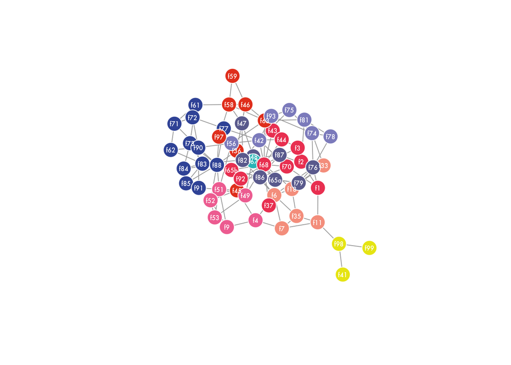

Compared with the investigators’ graph, the communities detected by the Girvan-Newman algoritm appear to be more consistent with the topology of the graph.

### Applying the Fast Greedy Algorithm

I applied the fast greedy algoritm described in Cluaset et al. (2004) with a call to the igraph package’s `cluster_fast_greedy` function. The implentation in igraph requires that the graph first be converted to an undirected graph. I accomplished this through a call to `as.undirected`. The resulting division of the graph into communities produced a modularity of 0.49. A plot of the graph showing the new community divisions follows.

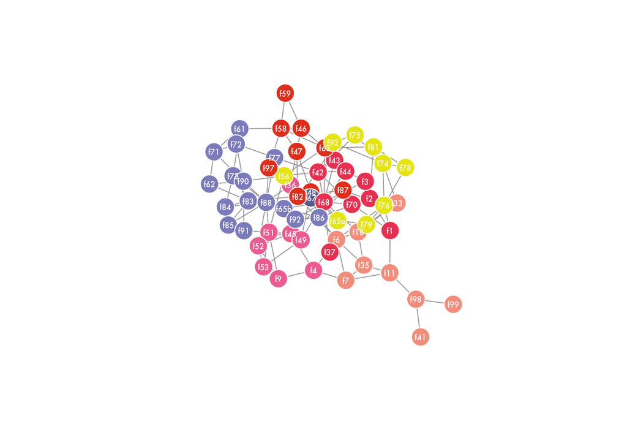

### Applying the Propogating Labels Algorithm

I applied the propogating labels algorithm described in Raghavan et al. (2007) with a call to the igraph package’s `cluster_label_prop` function. The principal beneift of this alorithm is its speed, although that benefit is not evident when the algorithm is applied to this fairly modest graph. As with the fast greedy algorithm, the implentation of the propograting labels algorithm in igraph requires that the graph first be converted to an undirected graph. The resulting division of the graph into communities produced a modularity of 0.47. A plot of the graph showing the new community divisions follows.

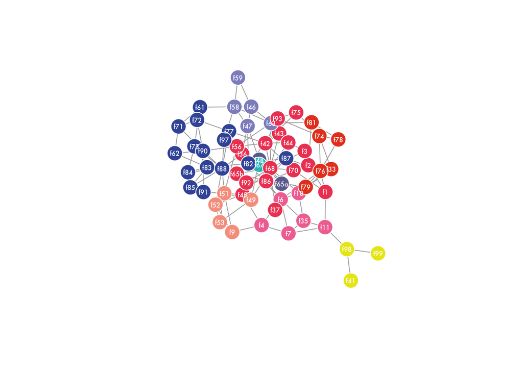

The algrithm opens with random label assignment, so the resulting memberships and modularity vary from run to run. In general, the resulting modularities are comperable to those returned by applying the Girvan-Newman algroithm.

### Applying the Louvain Algorithm in Gephi

I imported the Attiro network as an undirected graph in Gephi and applied the Lovuvian algorithm to detect communities. Like the igraph package in R, Gephi attempted to treat the edge types as weights. In applying the algorithm, I neglected these weights. I exported the resulting groupings as a CSV file and imported them into R for analysis. The resulting division into groups is shown in the plot below.

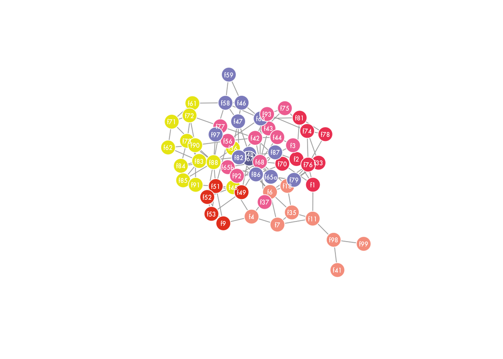